# Advanced Research Dataset Homeworks

Gerardo A. Casteleiro, MS, LMHC

10/29/2019

# Dataset 1 - Multiple Regression

### 1. Load the data file called EX9Q1.sav. This is a demonstration data file which for many years was supplied with every copy of SPSS (and called ‘1991 U.S. General Social Survey.sav’) but is not with recent versions.

### 1.a. Open the data file and familiarise yourself with the variables. This file contains more than 40 variables for each of about 1500 respondents.

```r
#import the dataset
EX9Q1 <- read_sav("EX9Q1(1).sav")

#check for missing data
any(is.na(EX9Q1))
```

```
## [1] TRUE
```

```r
#check the data variable names
names(EX9Q1)
```

```
##  [1] "sex"      "race"     "region"   "happy"    "life"     "sibs"
##  [7] "childs"   "age"      "educ"     "paeduc"   "maeduc"   "speduc"
## [13] "prestg80" "occcat80" "tax"      "usintl"   "obey"     "popular"
## [19] "thnkself" "workhard" "helpoth"  "hlth1"    "hlth2"    "hlth3"
## [25] "hlth4"    "hlth5"    "hlth6"    "hlth7"    "hlth8"    "hlth9"
## [31] "work1"    "work2"    "work3"    "work4"    "work5"    "work6"
## [37] "work7"    "work8"    "work9"    "prob1"    "prob2"    "prob3"
## [43] "prob4"    "filter_$"
```

```r
#count missing data
length(which(is.na(EX9Q1)))
```

```
## [1] 21033
```

### 1.b. The variable “prestg80” is a scale variable which codes the respondent’s occupational prestige score (a higher value indicates a more prestigious occupation). We are going to investigate which other variables predict the occupational prestige score. Undertake a multiple regression to determine whether occupational prestige is predicted by the variables listed below, but first check the nominal variables for whether or not they are dichotomous (for example, use Frequencies). You will find one that is not dichotomous, and you should decide how to deal with that. You could: produce dummy variables; collapse two categories into one; or, as one category has proportionately low N, just exclude that category. Justify your decision. Predictors: respondent’s sex, their race, their general happiness (happy), the number of children they have (childs), the highest year of school completed (educ), and whether the respondent takes illegal drugs (hth5) or has a drinking problem (hlth4)

Below the data is checked. Then the multiple regression model with `lm` (linear model) is fitted and tested.

```r
#check nominal variables for dichotomy
table(EX9Q1$sex)
```

```
##
##   1   2
## 636 881
```

```r
table(EX9Q1$happy) #level of happiness
```

```
##
##   1   2   3
## 467 872 165
```

```r
table(EX9Q1$childs) #no. of children
```

```
##
##   0   1   2   3   4   5   6   7   8
## 419 255 375 215 127  54  24  23  17
```

```r
table(EX9Q1$educ) #highest yr hs completed
```

```
##
##   0   3   4   5   6   7   8   9  10  11  12  13  14  15  16  17  18  19
##   2   5   5   6  12  25  68  56  73  85 461 130 175  73 194  43  45  22
##  20
##  30
```

```r
table(EX9Q1$hlth5) #illegal drugs
```

```
##
##   1   2
##  30 982
```

```r
table(EX9Q1$hlth4) #drinking problem
```

```
##
##   1   2
##  17 995
```

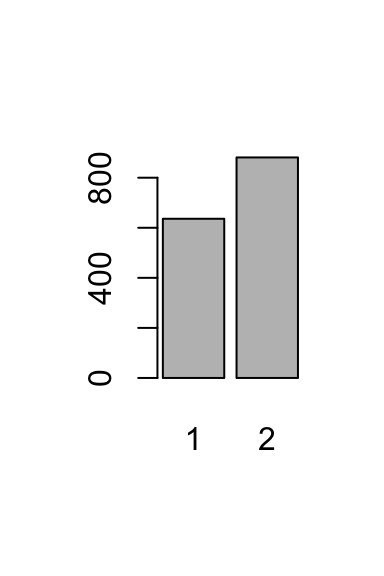

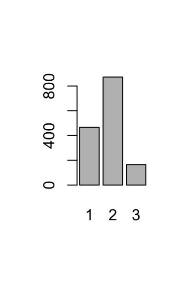

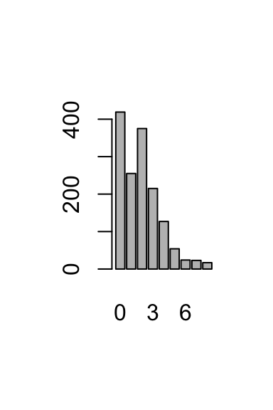

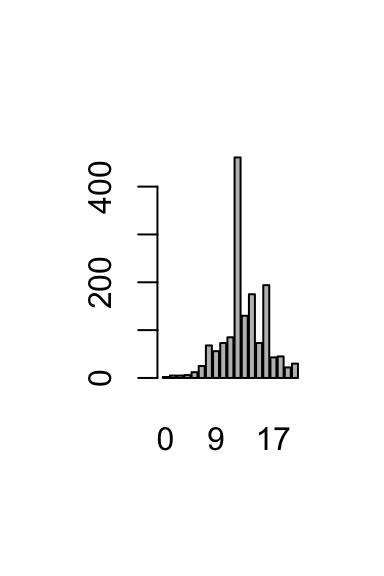

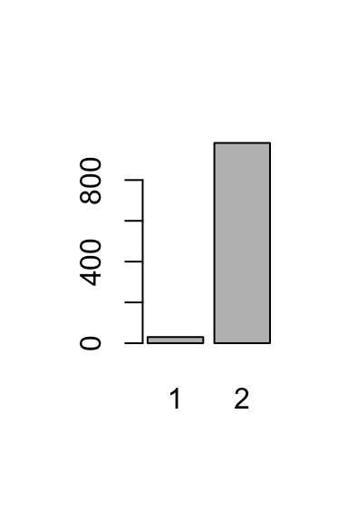

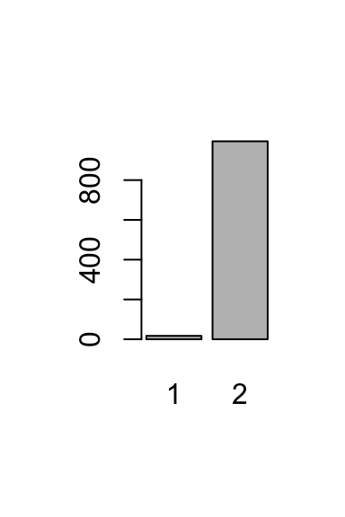

```r
tablist <- list(
table(EX9Q1$sex),
table(EX9Q1$happy), #level of happiness
table(EX9Q1$childs), #no. of children
table(EX9Q1$educ), #highest yr hs completed
table(EX9Q1$hlth5), #illegal drugs
table(EX9Q1$hlth4) #drinking problem
)
#plots
for(i in 1:length(tablist)){
  barplot(tablist[[i]])
}
```

```r
#OR: lapply(tablist,barplot)

table(EX9Q1$race) #race is nominal and not dichotomous (1 = "white" 2 = "black" 3 = "other")
```

```
##
##    1    2    3
## 1264  204   49
```

```r
#for race variable, use: as.factor(EX9Q1$race)

#fit model
mr.fit <- lm(formula = prestg80 ~ sex + happy + childs + educ + hlth5 +
    hlth4 + as.factor(race), data = EX9Q1)
#check model
summary(mr.fit)
```

```
##
## Call:
## lm(formula = prestg80 ~ sex + happy + childs + educ + hlth5 +
##     hlth4 + as.factor(race), data = EX9Q1)
##
## Residuals:
## <Labelled double>: R's Occupational Prestige Score (1980)
##     Min      1Q  Median      3Q     Max
## -33.809  -8.108  -0.080   7.720  29.685
##
## Labels:
##  value     label
##      0 DK,NA,NAP
##
## Coefficients:
##                  Estimate Std. Error t value Pr(>|t|)
## (Intercept)       -0.9155     7.0683  -0.130  0.89697
## sex               -0.6774     0.7466  -0.907  0.36448
## happy             -0.7166     0.6020  -1.190  0.23418
## childs             0.1481     0.2247   0.659  0.51008
## educ               2.2227     0.1301  17.090  < 2e-16 ***
## hlth5              7.0864     2.1698   3.266  0.00113 **
## hlth4              2.0384     2.8497   0.715  0.47459
## as.factor(race)2  -4.1639     1.1152  -3.734  0.00020 ***
## as.factor(race)3  -2.0058     2.1801  -0.920  0.35779
## ---
## Signif. codes:  0 '***' 0.001 '**' 0.01 '*' 0.05 '.' 0.1 ' ' 1
##
## Residual standard error: 11.1 on 924 degrees of freedom
##   (584 observations deleted due to missingness)
## Multiple R-squared:  0.2864, Adjusted R-squared:  0.2802
## F-statistic: 46.36 on 8 and 924 DF,  p-value: < 2.2e-16
```

We can go some steps further. Just because this model is significant doesn’t mean it’s the one we should use; it’s definitely not the most parsimonious.

```r
#backward model selection could result in a better model
#(feel free to skip this entire section)

drop1(mr.fit)
```

|  | Df | Sum of Sq | RSS | AIC |
| --- | --- | --- | --- | --- |
|  | NA | NA | 113922.9 | 4500.946 |
| sex | 1 | 101.49545 | 114024.4 | 4499.776 |
| happy | 1 | 174.72419 | 114097.6 | 4500.375 |
| childs | 1 | 53.53974 | 113976.4 | 4499.384 |
| educ | 1 | 36008.45455 | 149931.4 | 4755.199 |
| hlth5 | 1 | 1315.04367 | 115238.0 | 4509.654 |
| hlth4 | 1 | 63.08809 | 113986.0 | 4499.462 |
| as.factor(race) | 2 | 1770.75233 | 115693.7 | 4511.336 |